# FEF Data Analysis Jan 2025

Alisa Hove

2025-01-11

## Project Description

Foliar endophytic fungi (FEF) live within leaves without causing visible signs of disease in their host. FEFs occur in all vascular land plants, yet the exact nature of interactions between specific FEF taxa and their hosts is not well understood. Some FEF are associated with increased host fitness through enhanced water use efficiency, nutrient acquisition and production of defensive compounds. However, some FEF may become detrimental to the host under high-stress conditions. In 2022, we examined a series of leaf ecophysiological traits in sweet birch (Betula lenta, Fagaceae) along an elevation gradient, across three forested mountain slopes near Asheville, North Carolina, USA. We have a separate data set focused on FEF identification using morphotypes and Sanger sequencing of the ITS 1 and 2 regions.

VARIABLES:

STATISTICAL ANALYSIS: Linear regression was used to look for correlations between elevation as an independent variable, and photosynthetic rate, transpiration rate, and WUEi, as the response variables. Nested ANOVAs were used to look for significant effects of Site, Tree(Site), and Leaf(Tree(Site)) on each leaf functional trait; photosynthetic rate, transpiration rate, and WUEi. Tukey HSD tests were used to compute confidence intervals for differences between mean leaf functional traits in pairwise comparisons of Sites.

This project is a collaboration with Grace Dougherty, Grace Zaboski, and ALisa Hove.

## Data Cleaning: Load libraries, read in data and filter out zeros

```r
library(readr)
library(dplyr)
```

```r
library(tidyr)
library(ggplot2)
library(viridisLite)
library(RColorBrewer)
BELE_GE_data <- read_csv("~/Desktop/FEF Manuscript Materials 2025/Analysis/BELE-GE-data.csv")
View(BELE_GE_data)
data <- dplyr::filter(BELE_GE_data, Photo >= 1) # force it to use dplyr filter() function
View(data)
```

Test for normal distribution of w/ shapiro test:  
(shapiro test rejects the hypothesis of normality when the p-value is less than or equal to 0.05.)

```r
shapiro.test(data$Photo) # NOT normal
```

```
##
##  Shapiro-Wilk normality test
##
## data:  data$Photo
## W = 0.93504, p-value = 0.002976
```

```r
shapiro.test(data$Trans) # NOT normal
```

```
##
##  Shapiro-Wilk normality test
##
## data:  data$Trans
## W = 0.8739, p-value = 1.447e-05
```

```r
shapiro.test(data$WUEi)  # IS normal
```

```
##
##  Shapiro-Wilk normality test
##
## data:  data$WUEi
## W = 0.96206, p-value = 0.05587
```

Photosynthetic rate and transpiration rate are NOT normally distributed (p-value < 0.05), WUEi IS (p-value > 0.05).

## Analysis of Site Effects on Photosynthetic Rates (A, µmol CO2 m-2 s-1)

Test for normality. Photo was log transformed

```r
log.Photo <- log10(data$Photo)
shapiro.test(log.Photo)
```

```
##
##  Shapiro-Wilk normality test
##
## data:  log.Photo
## W = 0.94723, p-value = 0.01067
```

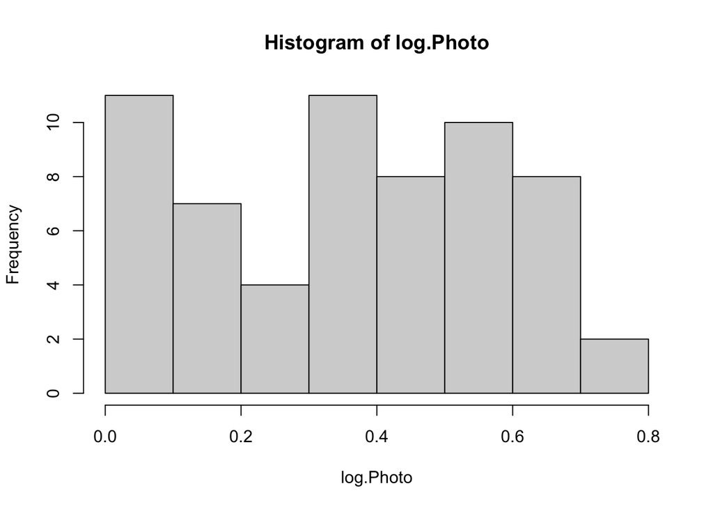

```r
hist(log.Photo)
```

Nested ANOVA on Log-Photo

```r
log.Photo.res <- aov(log.Photo ~ SITE + Plant_ID/SITE + Leaf.number/Plant_ID/SITE, data = data)
summary(log.Photo.res)
```

```
##                           Df Sum Sq Mean Sq F value Pr(>F)
## SITE                       2 0.2926 0.14629   3.572 0.0353 *
## Plant_ID                   1 0.0038 0.00384   0.094 0.7608
## Leaf.number                1 0.0036 0.00362   0.088 0.7675
## SITE:Plant_ID              2 0.2235 0.11177   2.729 0.0748 .
## Plant_ID:Leaf.number       1 0.0209 0.02090   0.510 0.4783
## SITE:Plant_ID:Leaf.number  2 0.0615 0.03076   0.751 0.4769
## Residuals                 51 2.0886 0.04095
## ---
## Signif. codes:  0 '***' 0.001 '**' 0.01 '*' 0.05 '.' 0.1 ' ' 1
```

```r
log.Photo.res
```

```
## Call:
##    aov(formula = log.Photo ~ SITE + Plant_ID/SITE + Leaf.number/Plant_ID/SITE,
##     data = data)
##
## Terms:
##                      SITE  Plant_ID Leaf.number SITE:Plant_ID
## Sum of Squares  0.2925720 0.0038365   0.0036176     0.2235418
## Deg. of Freedom         2         1           1             2
##                 Plant_ID:Leaf.number SITE:Plant_ID:Leaf.number Residuals
## Sum of Squares             0.0208989                 0.0615273 2.0885554
## Deg. of Freedom                    1                         2        51
##
## Residual standard error: 0.2023662
## Estimated effects may be unbalanced
```

Use Tukey HSD test to figure out which sites differ, and to compute confidence intervals for the differences in mean photosynthetic rate between sites:

```r
TukeyHSD(log.Photo.res, "SITE")
```

```
##   Tukey multiple comparisons of means
##     95% family-wise confidence level
##
## Fit: aov(formula = log.Photo ~ SITE + Plant_ID/SITE + Leaf.number/Plant_ID/SITE, data = data)
##
## $SITE
##                                        diff         lwr       upr     p adj
## Green Top (GT)-Big Ivy (BI)      0.16284223  0.00205463 0.3236298 0.0465291
## Shope Creek (SC)-Big Ivy (BI)    0.12092361 -0.02326583 0.2651130 0.1166302
## Shope Creek (SC)-Green Top (GT) -0.04191862 -0.20549304 0.1216558 0.8106264
```

The confidence interval between GT & BI is strictly positive, and p-val < 0.05, showing that GT has a significantly higher photosynthetic rate than BI. The confidence intervals between SC & BI and SC & GT contain zero and have p-vals > 0.05, showing no significant differences in photosynthesis.

## Analysis of Site Effects on Transpiration Rates

Transpiration rate (log-transformed):

```r
log.Trans <- log10(data$Trans)
shapiro.test(log.Trans)
```

```
##
##  Shapiro-Wilk normality test
##
## data:  log.Trans
## W = 0.98068, p-value = 0.4468
```

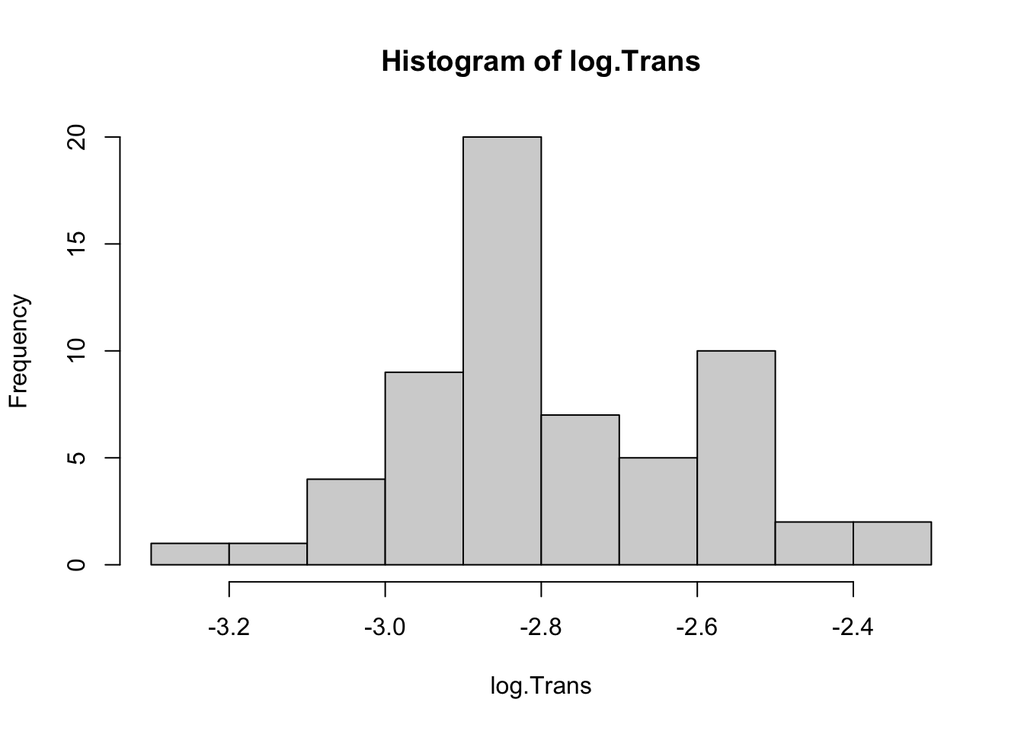

```r
hist(log.Trans)
```

Nested ANOVA on log.trans

```r
log.Trans.res <- aov(log.Trans ~ SITE + Plant_ID/SITE + Leaf.number/Plant_ID/SITE, data = data)
summary(log.Trans.res)
```

```
##                           Df Sum Sq Mean Sq F value   Pr(>F)
## SITE                       2 0.5960 0.29800  12.158 4.81e-05 ***
## Plant_ID                   1 0.0016 0.00160   0.065   0.7996
## Leaf.number                1 0.0054 0.00542   0.221   0.6401
## SITE:Plant_ID              2 0.2461 0.12303   5.019   0.0102 *
## Plant_ID:Leaf.number       1 0.0383 0.03832   1.563   0.2169
## SITE:Plant_ID:Leaf.number  2 0.0173 0.00866   0.353   0.7039
## Residuals                 51 1.2501 0.02451
## ---
## Signif. codes:  0 '***' 0.001 '**' 0.01 '*' 0.05 '.' 0.1 ' ' 1
```

```r
log.Trans.res
```

```
## Call:
##    aov(formula = log.Trans ~ SITE + Plant_ID/SITE + Leaf.number/Plant_ID/SITE,
##     data = data)
##
## Terms:
##                      SITE  Plant_ID Leaf.number SITE:Plant_ID
## Sum of Squares  0.5959989 0.0015967   0.0054231     0.2460508
## Deg. of Freedom         2         1           1             2
##                 Plant_ID:Leaf.number SITE:Plant_ID:Leaf.number Residuals
## Sum of Squares             0.0383210                 0.0173285 1.2500813
## Deg. of Freedom                    1                         2        51
##
## Residual standard error: 0.1565612
## Estimated effects may be unbalanced
```

The p-values, Pr(>F), for site and tree(site) are small; so there is a significant difference in mean transpiration rate between some sites and some tree(site) interactions.

Use Tukey HSD test to figure out which Site interactions differ, and to compute confidence intervals for the differences in mean transpiration rate between sites:

Tree(Site):

```r
TukeyHSD(log.Trans.res, as.factor("SITE:Plant_ID"))
```

[output not shown]

The confidence intervals between GT & BI, and between SC & BI are strictly positive, and p-vals < 0.05, showing that GT has significantly higher mean transpiration rate than BI, and that SC has significantly higher mean transpiration rate than BI. The confidence intervals between SC & GT contain zero and has a p-val > 0.05, showing no significant differences in mean transpiration rate between SC & GT.

## Analysis of Site Effects on WUE

```r
WUEi.res<-aov(WUEi ~ SITE + Plant_ID/SITE + Leaf.number/Plant_ID/SITE, data = data)
WUEi.res
```

```
## Call:
##    aov(formula = WUEi ~ SITE + Plant_ID/SITE + Leaf.number/Plant_ID/SITE,
##     data = data)
##
## Terms:
##                       SITE   Plant_ID Leaf.number SITE:Plant_ID
## Sum of Squares  0.01227218 0.00039703  0.00175255    0.00048854
## Deg. of Freedom          2          1           1             2
##                 Plant_ID:Leaf.number SITE:Plant_ID:Leaf.number  Residuals
## Sum of Squares            0.00057095                0.00548172 0.09882999
## Deg. of Freedom                    1                         2         51
##
## Residual standard error: 0.04402094
## Estimated effects may be unbalanced
```

```r
summary(WUEi.res)
```

```
##                           Df  Sum Sq  Mean Sq F value Pr(>F)
## SITE                       2 0.01227 0.006136   3.166 0.0506 .
## Plant_ID                   1 0.00040 0.000397   0.205 0.6527
## Leaf.number                1 0.00175 0.001753   0.904 0.3461
## SITE:Plant_ID              2 0.00049 0.000244   0.126 0.8818
## Plant_ID:Leaf.number       1 0.00057 0.000571   0.295 0.5896
## SITE:Plant_ID:Leaf.number  2 0.00548 0.002741   1.414 0.2524
## Residuals                 51 0.09883 0.001938
## ---
## Signif. codes:  0 '***' 0.001 '**' 0.01 '*' 0.05 '.' 0.1 ' ' 1
```

P-values, Pr(>F), are all > 0.05); showing that there are no significant model effects on WUEi. It should be noted that the effect of site has a P-value of 0.0506, suggesting that there may be some site differences, but we did not detect them witho our study design.

## Analysis of the effects of elevation on gas exchange rates. We took the mean gas exchange rate for each tree (n = 3 leaves / tree) and then regressed this on elevation (m).

```r
#Create a mean.photo data frame where each tree at each site has a mean gas exchange rate.
mean.photo <- data %>%
  group_by(SITE, Plant_ID, `Elevation (m)`) %>%
  summarize(mean.photo.rate = mean(Photo, na.rm = TRUE))
View(mean.photo)

#Do the same for Transpiration
mean.trans <- data %>%
  group_by(SITE, Plant_ID, `Elevation (m)`) %>%
  summarize(mean.trans = mean(Trans, na.rm = TRUE))
View(mean.trans)

# Do the same for WUEi
mean.WUEi <- data %>%
  group_by(SITE, Plant_ID, `Elevation (m)`) %>%
  summarize(mean.WUEi = mean(WUEi, na.rm = TRUE))
View(mean.WUEi)
```

##Photosynthetic Rates are not significantly correlated with elevation (linear regression, lm method)

```r
shapiro.test(mean.photo$mean.photo.rate) # is normally distributed
```

```
##
##  Shapiro-Wilk normality test
##
## data:  mean.photo$mean.photo.rate
## W = 0.93855, p-value = 0.1514
```

```r
reg.photo <- lm(mean.photo.rate ~ `Elevation (m)`, data = mean.photo)
summary(reg.photo)
```

```
##
## Call:
## lm(formula = mean.photo.rate ~ `Elevation (m)`, data = mean.photo)
##
## Residuals:
##      Min       1Q   Median       3Q      Max
## -1.64327 -0.80998 -0.02474  0.50969  1.85451
##
## Coefficients:
##                  Estimate Std. Error t value Pr(>|t|)
## (Intercept)      6.874982   2.875014   2.391   0.0258 *
## `Elevation (m)` -0.004688   0.003027  -1.549   0.1357
## ---
## Signif. codes:  0 '***' 0.001 '**' 0.01 '*' 0.05 '.' 0.1 ' ' 1
##
## Residual standard error: 1.011 on 22 degrees of freedom
## Multiple R-squared:  0.0983, Adjusted R-squared:  0.05732
## F-statistic: 2.398 on 1 and 22 DF,  p-value: 0.1357
```

# Transpiration Rates are negatively correlated with elevation (Spearman Rank Test)

```r
shapiro.test(mean.trans$mean.trans) # is NOT normally distributed
```

```
##
##  Shapiro-Wilk normality test
##
## data:  mean.trans$mean.trans
## W = 0.90475, p-value = 0.02718
```

```r
# use a Spearman Rank Test
spearman_trans <- cor.test(mean.trans$`Elevation (m)`, mean.trans$mean.trans, method = "spearman")
print(spearman_trans)
```

```
##
##  Spearman's rank correlation rho
##
## data:  mean.trans$`Elevation (m)` and mean.trans$mean.trans
## S = 3322.1, p-value = 0.02958
## alternative hypothesis: true rho is not equal to 0
## sample estimates:
##        rho
## -0.4443963
```